# Relatorio - certo

Jonatha Azevedo e Leonardo Filgueira

November 29, 2017

```r
require(BETS)
dados <-  BETS.sidra.get(x = c(3653), from = c("200201"), to = c("201710"), territory = "brazil",
                         variable = 3135, sections = c(129316), cl = 544)
dados <- ts(dados$serie_3653$Valor,start = c(2002,01),frequency = 12)
```

## Análise gráfica

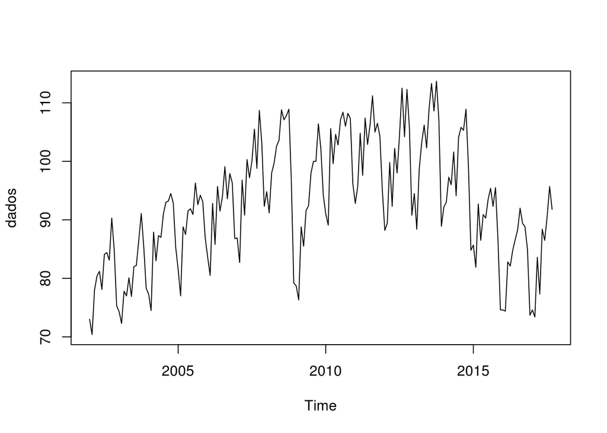

```r
plot.ts(dados)
```

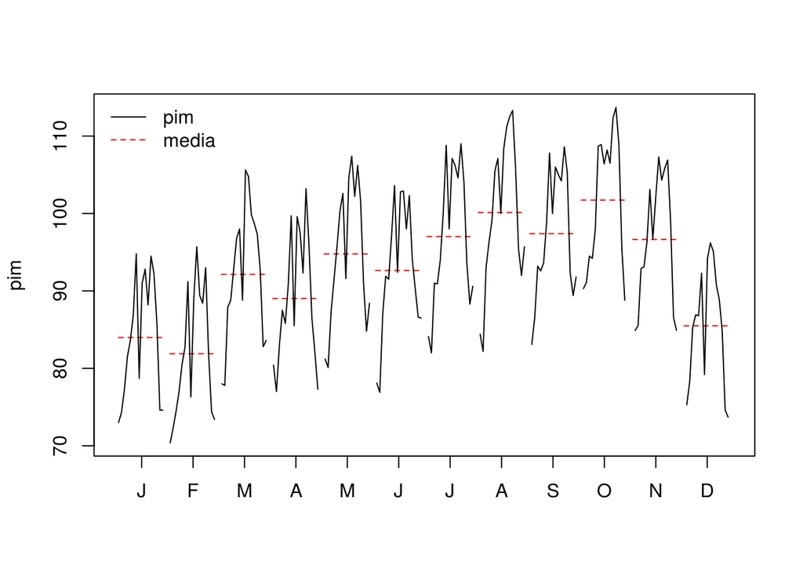

```r
pim = dados
monthplot(pim,col.base=2,lty.base=2)
legend("topleft",legend=c("pim","media"),lty=c(1,2),col=c(1,2),bty="n")
```

Com o auxilio do gráfico podemos verificar que:

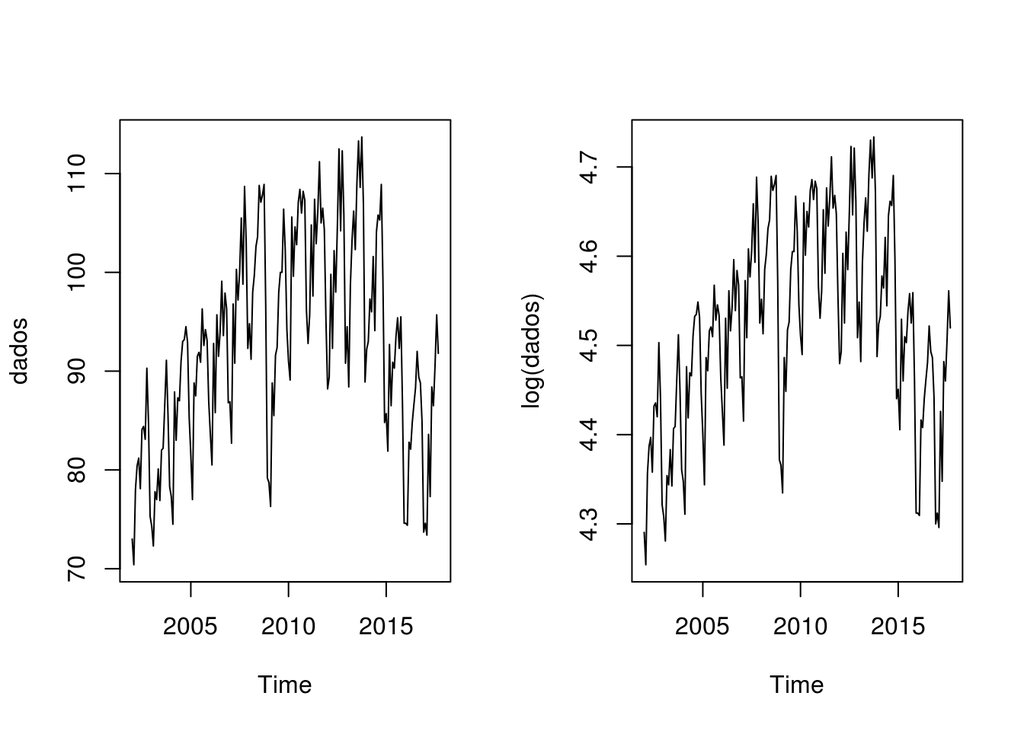

```r
par(mfrow=c(1,2))
plot.ts(dados)
plot.ts(log(dados))
```

- Não há mudança de variabilidade quando transformamos os dados, passando o logaritmo.

## Decomposição

Podemos utilizar o comando `decompose` para verificar algumas componentes não tão claros com o plot.ts, ou seja, podemos verificar:

- tendência + ciclo
- sazonalidade
- erro (resíduo)

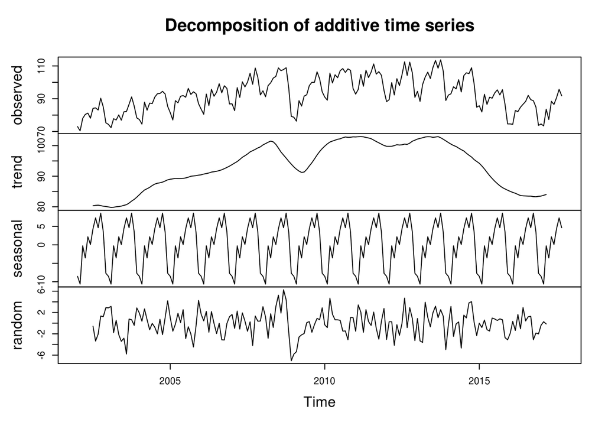

```r
plot(decompose(pim))
```

No gráfico, podemos verificar uma tendencia positiva, mas um quebra estrutural causada pela crise economica de 2008. Podemos verificar que realmente há sazonalidade na série temporal.

Agora, temos que vereficiar a estacionáriedade da parte não sazonal e da parte sazonal.

### Parte não sazonal

Há quatro maneiras de observar se a série temporal em estudo é ou não estacionária:

- Análise gráfica;
- Comparação da média e da variância da ST para diferentes períodos de tempo;
- Observação da FAC (função de autocorrelação)
- Testes de raiz unitária

```r
BETS.corrgram(pim,lag.max=48)
```

[output not shown]